# Unit 1 - Modelling and Representations of Systems

### Part 4 - Frequency Domain

- Modelling of electrical and mechanical systems
  - Electric circuits with resistors, capacitors, inductors, op-amps
  - Translational mechanical systems
  - Rotational mechanical systems
- Representations
  - Frequency domain
- Key Concept
  - Poles
  - Zeros
- Plots
  - Bode

[figure not shown]

source: https://en.wikipedia.org/wiki/Joseph_Fourier

- March 21 1768 - May 16 1830
- Fourier accompanied Napoleon Bonaparte on his Egyptian expedition in 1798, as scientific adviser
- Known for initiating the investigation of Fourier series
- Applications to problems of heat transfer and vibrations

[figure not shown]

source: https://en.wikipedia.org/wiki/Hendrik_Wade_Bode

- December 24 1905 to June 21 1982
- pioneer of modern control theory and electronic telecommunications
- His synergy with Claude Shannon, the father of information theory, laid the foundations for the technological convergence of the information age
- Contributions to the design, guidance and control of anti-aircraft systems during World War II
- During the Cold War, he contributed to the design and control of missiles and anti-ballistic missiles

### What is frequency domain?

Based on two facts:

- every signal can be expressed as a weighted sum of sinusoids of different frequencies,
- for a sinusoidal input, the output of a LTI system is a sinusoid at the same frequency, but with different magnitude and phase.

```
Poles of system: [-0.5+1.32287566j -0.5-1.32287566j]
```

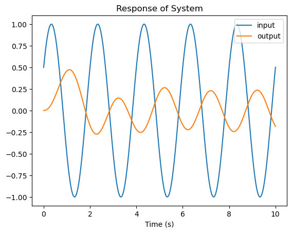

```python
import math
import numpy as np
import control as ct
import matplotlib.pyplot as plt
import enel441_utilities as eu
import scipy as sp

den_sys = np.array([1, 1, 2])
num_sys = np.array([2])

print('Poles of system:', np.roots(den_sys))

N = 10000
dt = 1/1000
t = np.linspace(0,dt*N,N)

f = 0.5   #frequency of sinusoid
theta = math.pi/6
u_sinusoid = np.sin(2*math.pi*f*t + theta)

# simulate the system output for selected input signal (note initial conditions are assumed to be zero)
sys = ct.TransferFunction(num_sys,den_sys)
tout, yout = ct.forced_response(sys,U=u_sinusoid,T=t)

# plot the response
fig, ax = plt.subplots(1,1)
ax.plot(t, u_sinusoid, label='input')
ax.plot(tout, yout, label='output')
ax.set_title('Response of System')
ax.set_xlabel('Time (s)')
plt.legend()

plt.show()
```

### Transforming between representations - The Formula's

From time domain to frequency domain: Continuous Time Fourier Transform. $$ \begin{align*} Y(j \omega) = \int_{-\infty}^{\infty} y(t) e^{-j \omega t} dt \end{align*} $$

Frequency Domain to time domain: Inverse Continuous Time Fourier Transform $$ \begin{align*} y(t) = \frac{1}{2 \pi} \int_{-\infty}^{\infty} Y(j \omega) e^{j \omega t} \end{align*} $$

Laplace to Frequency domain: $$ \begin{align*} G(j \omega) = G(s) \Big |_{s=j \omega} \end{align*} $$

Frequency to Laplace domain: $$ \begin{align*} G(s) = G(j \omega) \Big |_{j \omega = s} \end{align*} $$

### Transforming Between Representations - Interpretation

I would like to have a better understanding of where the substitution $s=j\omega$ comes from.

Reasoning:

1. When the input to a linear time-invariant system is a sinusoid of frequency $\omega$ with magnitude $1$ and phase shift $0$rad, then the output of the system is a sinusoid at that frequency with a different magnitude and phase shift.
2. The frequency response is a plot of this magnitude change and phase shift for each frequency.

In equations: Output of a system when the input is a sinusoid of frequency $\omega$ with unit magnitude and zero phase shift: $$ \begin{align*} Y(s) &= G(s)U(s) \\ &= G(s)\frac{\omega}{s^2 + \omega^2} \end{align*} $$

Do a partial partial fraction expansion of the right hand side to separate the sinusoid: $$ G(s)\frac{\omega}{s^2 + \omega^2} = AG(s) + \frac{Bs + C}{s^2 + \omega^2} $$ Need to solve for $A$, $B$, and $C$. Multiply both sides by $s^2+\omega^2$: $$ G(s)\omega = A(s^2+\omega^2)G(s)+ Bs + C $$ Let $s=j \omega$: $$ G(j\omega)\omega = j\omega B + C $$ Let $s=-j \omega$: $$ G(-j\omega)\omega = -j\omega B + C $$

Using the above equations, it is possible to solve for $B$ and $C$: $$ \begin{align*} B &= \frac{G(j \omega)- G(-j \omega)}{j 2} \\ &= \text{Imag}( G(j \omega)) \end{align*} $$ and $$ \begin{align*} C &= \omega \frac{G(j \omega)+ G(-j \omega)}{2} \\ &= \omega \text{Real}( G(j \omega)) \end{align*} $$ We can express $G(s)$ using a partial fraction expansion: $$ G(s) = \sum_{n=0}^P \frac{A_n}{s+p_n}, $$ where $p_0$, $\ldots$, $p_n$ are the poles of $G(s)$.

So we have the following expression for $Y(s)$: $$ Y(s) = \sum_{n=0}^P \frac{A A_n}{s+p_n} + \text{Imag}( G(j \omega)) \frac{s}{s^2 + \omega^2} + \text{Real}(G(j \omega))\frac{\omega}{s^2 + \omega^2} $$ Take the inverse Laplace transform: $$ y(t) = \sum_{n=0}^P AA_n e^{-p_nt} + \text{Imag}( G(j \omega)) \cos(\omega t) + \text{Real}(G(j \omega)) \sin(\omega t) $$ This can be simplified using the following trigonometric identity: $$ d_1 \cos(x) + d_2 \sin(x) = d_3 \sin(x + \phi), $$ where $$ \begin{align*} d_3^2 &= d_1^2 + d_2^2 \\ \phi &= \text{atan}(\frac{d_1}{d_2}) \end{align*} $$

The transient response will eventially decay to zero. So for large, $t$, we have only the steady state response. The steady state component of the output is equal to: $$ y_{ss}(t) \approx |G(j\omega)| \sin(\omega t + \angle G(j \omega)) $$ We have shown that, when the input to a system is a sinusoid of frequency $\omega$ rad/s, then the output is a sinusoid at that same frequency but with a different magnitude and phase.

Interestingly, the magnitude of the output sinusoid is $|G(s)|$ evaluated at $s=j \omega$ and the phase shift is $\angle G(s)$ evaluated at $s=j \omega$!

We have connected together:

- time domain: we applied a sinusoid of frequency $\omega$ to a system
- Laplace domain: we knew the transfer function of the system (and called it $G(s)$)
- Frquency domain: the output of the system was scaled by $|G(j \omega)|$ and phase shifted by $\angle G(j \omega)$

### Bode Plot - Visualizing the Frequency Domain

Bode plot consists of two plots:

- x-axis of both plots is frequency (usually in radians). Axis is logarithmic.
- y-axis of top plot is called the Magnitude plot.
- y-axis of bottom plot is called Phase plot.

To construct a Bode Plot of $G(s)$:

1. excite the system with a sinusoid of frequency $\omega$ with unit magnitude and known phase
2. determine the magnitude of phase shift of the output sinusoid
3. plot the magnitude of the output on the top plot (a point at frequency $\omega$)
4. plot the phase shift of the output on the bottom plot
5. Return to step one for a new frequency $\omega$.

### In Class Activity!

- Look at the Bode plots of various systems
  - Second order
  - systems with large poles, small zeros, and vice-versa
  - Higher order
  - Low pass
  - High pass
  - Notch filter

From the video's (or previous courses), based on the rules of constructing Bode Plots:

- How would we construct a Low-Pass System (a system where high frequencies are dampened)?
- How would we construct a High-Pass System (a system where low frequencies are dampened)?

### Try Make a First-Order Low-Pass System

```
1
[2.]
```

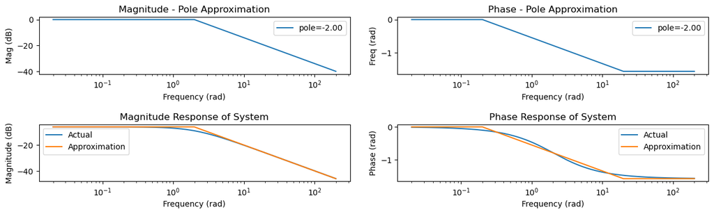

```python
# Try different systems

num = np.array([1])
den = np.array([1, 2])

N = 1000
omega = eu.enel441_get_reasonable_freq_range(num, den, N)
G_jw = eu.enel441_fourier_transform(num,den,omega)
eu.enel441_approximate_bode(num,den,omega)
```

### Try Make a High-Pass System

```
1
[3.]
```

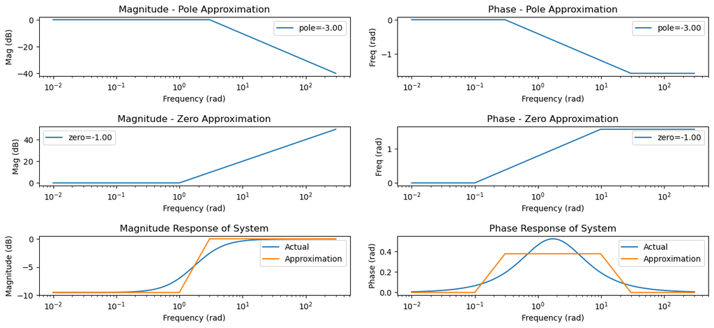

```python
# Try different systems

num = np.array([1, 1])
den = np.array([1, 3])

N = 1000
omega = eu.enel441_get_reasonable_freq_range(num, den, N)
G_jw = eu.enel441_fourier_transform(num,den,omega)
eu.enel441_approximate_bode(num,den,omega)
```

### Try Make a Pass-Band System

```
[  1.  100.1  10. ]
[ 1  8 15]
[-5. -3.]
[-5. -3.]
2
[5. 3.]
```

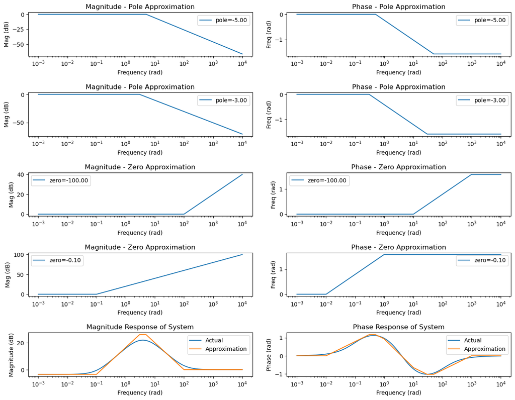

```python
# Try different systems


poles = np.array([-3, -5])
zeros = np.array([-0.1, -100])
num = eu.roots_to_polynomial(zeros)
den = eu.roots_to_polynomial(poles)


print(num)
print(den)
print(np.roots(den))
print(np.roots(den))




N = 1000
omega = eu.enel441_get_reasonable_freq_range(num, den, N)
G_jw = eu.enel441_fourier_transform(num,den,omega)
eu.enel441_approximate_bode(num,den,omega)
```

### Try Different Second-order systems

What do you notice about the approximate version of the Bode Plot? When is the approximation worst? What affects the resonant peak?

```
[1]
[1.0000e+00 1.0000e+01 4.0025e+04]
2
[200.06249024 200.06249024]
```

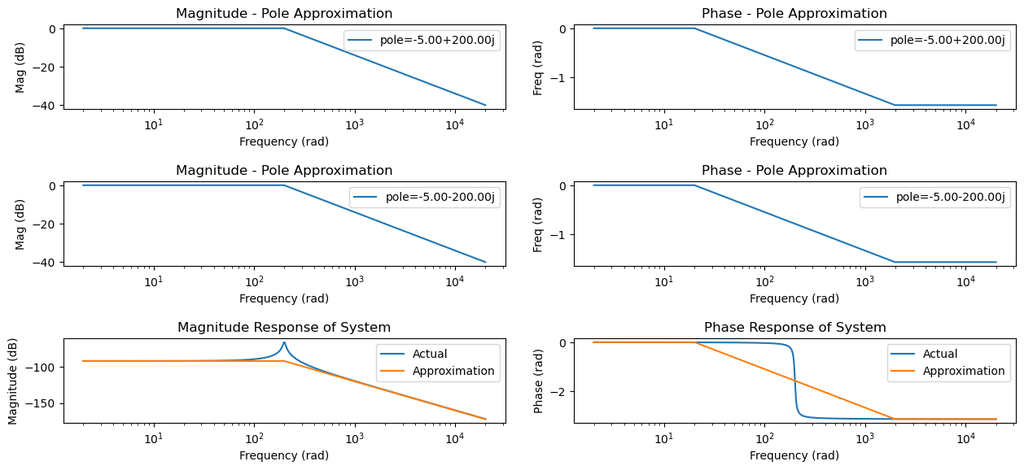

```python
# Try different systems

# Complex poles/zeros:
# vary value of imaginary part of the pole. What happens to the actual vs approximate responses?
p_re = -5
p_im = 200
num = np.array([1])
den = eu.roots_to_polynomial([complex(p_re,p_im), complex(p_re,-p_im)])
print(num)
print(den)

N = 1000
omega = eu.enel441_get_reasonable_freq_range(num, den, N)
G_jw = eu.enel441_fourier_transform(num,den,omega)
eu.enel441_approximate_bode(num,den,omega)
```

### Signal vs System

Output of a system in Frequency Domain is: $Y(j\omega) = G(j \omega)U(j \omega)$

- $G(j \omega)$ can be determined from the transfer function (substituting $s=j\omega$).

What about $U(j \omega)$? What if it is a complicated signal, or a random signal?

It turns out that it is very efficient to calculate the Fourier Transform of a signal using a computer.

### Calculate Fourier Transform of a Signal

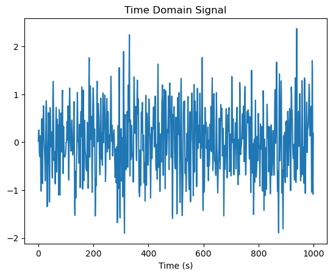

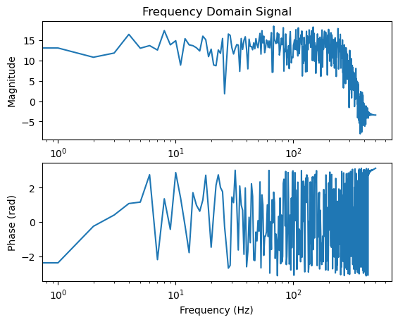

```python
import numpy as np
import matplotlib.pyplot as plt
import scipy as sp

N = 1000
Fs = 1/1000
t = np.linspace(0,1,1000)
f = np.linspace(0,1000,1000)

# Sinusoid
#u = np.sin(2*np.pi*5*t) + np.sin(2*np.pi*10*t)

# Random (Gaussian Noise)
#u = np.random.randn(N)

# Filtered Gaussian noise
[B,A] = sp.signal.butter(4,0.5,'low')
u = sp.signal.lfilter(B,A,np.random.randn(N))


U = np.fft.fft(u)

fig,ax = plt.subplots(1)
ax.set_title('Time Domain Signal')
ax.set_xlabel('Time (s)')
ax.plot(u)
fig,ax = plt.subplots(2,1)
ax[0].semilogx(f[0:int(N/2)], 10*np.log10(np.abs(U[0:int(N/2)])))
ax[0].set_xlabel('Frequency (Hz)')
ax[0].set_ylabel('Magnitude')
ax[0].set_title('Frequency Domain Signal')
ax[1].semilogx(f[0:int(N/2)], np.angle(U[0:int(N/2)]))
ax[1].set_xlabel('Frequency (Hz)')
ax[1].set_ylabel('Phase (rad)')
```

### Frequency Domain Representation

- Emphasizes which frequencies are attenuated, and which ones are amplified.
- This will be very useful throughout the remainder of the term.